Author: Tianze (Vincent) Luo  
Date : 2026-01-20

```python
%reset -f
import numpy as np
import matplotlib.pyplot as plt
import pandas as pd
from collections import defaultdict, Counter
import seaborn as sns
```

# Assignment 0: Look at your data!

### Due Thursday, January 20 at 11:59pm

This assignment primarily deals with different aspects of exploratory data analysis and aims to get you comfortable with it before moving onto further tasks involving preprocessing and model training. We are using data from the [TCGA](https://www.cancer.gov/ccg/research/genome-sequencing/tcga).

You will fill in the necessary code to answer the questions and upload your final notebook with code and output to Canvas.

# METABRIC Breast Cancer Dataset (40 points)

First, download and unpack the dataset at https://cbioportal-datahub.s3.amazonaws.com/brca_metabric.tar.gz. We will be focusing on only two files from here for now, `data_mrna_illumina_microarray.txt`, containing expression values and `data_mutations.txt`, containing information on mutated genes. However, the other files in this archive may by useful in undersrtanding what is in these files. For getting comfortable with continuous features, we will work with `data_mrna_illumina_microarray.txt`, and for discrete features, we will work with specific columns of `data_mutations.txt`. Perform the required functions throughout this assignment using pandas, matplotlib and/or seaborn. Use code cells to perform functions with a comment for each line explaining what it is doing and using intuitive variable names.

Note for this section we are showing you what the answers should be.

```python
!wget https://datahub.assets.cbioportal.org/brca_metabric.tar.gz
```

```
--2026-01-20 17:33:19--  https://datahub.assets.cbioportal.org/brca_metabric.tar.gz
Resolving datahub.assets.cbioportal.org (datahub.assets.cbioportal.org)... 2600:9000:2508:f600:1a:8960:1bc0:93a1, 2600:9000:2508:ac00:1a:8960:1bc0:93a1, 2600:9000:2508:ec00:1a:8960:1bc0:93a1, ...
Connecting to datahub.assets.cbioportal.org (datahub.assets.cbioportal.org)|2600:9000:2508:f600:1a:8960:1bc0:93a1|:443... connected.
HTTP request sent, awaiting response... 200 OK
Length: 510321901 (487M) [application/x-tar]
Saving to: ‘brca_metabric.tar.gz’

brca_metabric.tar.g 100%[===================>] 486.68M  33.1MB/s    in 13s

2026-01-20 17:33:33 (36.4 MB/s) - ‘brca_metabric.tar.gz’ saved [510321901/510321901]
```

```python
!tar xzvf brca_metabric.tar.gz
```

```
x brca_metabric/
x brca_metabric/Readme.txt
x brca_metabric/data_mutations.txt
x brca_metabric/LICENSE
x brca_metabric/data_mrna_illumina_microarray_zscores_ref_diploid_samples.txt
x brca_metabric/meta_gene_panel_matrix.txt
x brca_metabric/data_mrna_illumina_microarray.txt
x brca_metabric/meta_mrna_illumina_microarray.txt
x brca_metabric/meta_cna.txt
x brca_metabric/case_lists/
x brca_metabric/case_lists/cases_cna.txt
x brca_metabric/case_lists/cases_nat_comm_2016.txt
x brca_metabric/case_lists/cases_nature_2012.txt
x brca_metabric/case_lists/cases_sequenced.txt
x brca_metabric/case_lists/cases_mRNA.txt
x brca_metabric/case_lists/cases_all.txt
x brca_metabric/case_lists/cases_cnaseq.txt
x brca_metabric/case_lists/cases_complete.txt
x brca_metabric/meta_mutations.txt
x brca_metabric/meta_mrna_illumina_microarray_zscores_ref_diploid_samples.txt
x brca_metabric/data_clinical_patient.txt
x brca_metabric/data_gene_panel_matrix.txt
x brca_metabric/data_methylation_promoters_rrbs.txt
x brca_metabric/meta_study.txt
x brca_metabric/data_clinical_sample.txt
x brca_metabric/data_cna.txt
x brca_metabric/meta_methylation_promoters_rrbs.txt
x brca_metabric/meta_clinical_sample.txt
x brca_metabric/meta_clinical_patient.txt
```

```python
!pwd
!cat ./brca_metabric/Readme.txt
!ls -la ./brca_metabric
```

```
/Users/vincent/Desktop/COBB2060/hw/hw0
Gene panels for this study can be found here: https://github.com/cBioPortal/datahub/tree/master/reference_data/gene_panelstotal 2715440
drwxr-xr-x@ 22 vincent  staff        704 May  5  2025 .
drwxr-xr-x@  5 vincent  staff        160 Jan 20 17:35 ..
-rw-r--r--@  1 vincent  staff        455 May  5  2025 LICENSE
-rw-r--r--@  1 vincent  staff        122 May  5  2025 Readme.txt
drwxr-xr-x@ 10 vincent  staff        320 May  5  2025 case_lists
-rw-r--r--@  1 vincent  staff     408387 May  5  2025 data_clinical_patient.txt
-rw-r--r--@  1 vincent  staff     299020 May  5  2025 data_clinical_sample.txt
-rw-r--r--@  1 vincent  staff  106059807 May  5  2025 data_cna.txt
-rw-r--r--@  1 vincent  staff      52160 May  5  2025 data_gene_panel_matrix.txt
-rw-r--r--@  1 vincent  staff  276336736 May  5  2025 data_methylation_promoters_rrbs.txt
-rw-r--r--@  1 vincent  staff  689254852 May  5  2025 data_mrna_illumina_microarray.txt
-rw-r--r--@  1 vincent  staff  303120344 May  5  2025 data_mrna_illumina_microarray_zscores_ref_diploid_samples.txt
-rw-r--r--@  1 vincent  staff    4023586 May  5  2025 data_mutations.txt
-rw-r--r--@  1 vincent  staff        143 May  5  2025 meta_clinical_patient.txt
-rw-r--r--@  1 vincent  staff        141 May  5  2025 meta_clinical_sample.txt
-rw-r--r--@  1 vincent  staff        513 May  5  2025 meta_cna.txt
-rw-r--r--@  1 vincent  staff        152 May  5  2025 meta_gene_panel_matrix.txt
-rw-r--r--@  1 vincent  staff        606 May  5  2025 meta_methylation_promoters_rrbs.txt
-rw-r--r--@  1 vincent  staff        348 May  5  2025 meta_mrna_illumina_microarray.txt
-rw-r--r--@  1 vincent  staff        470 May  5  2025 meta_mrna_illumina_microarray_zscores_ref_diploid_samples.txt
-rw-r--r--@  1 vincent  staff        347 May  5  2025 meta_mutations.txt
-rw-r--r--@  1 vincent  staff        372 May  5  2025 meta_study.txt
```

### Q1: Continuous values (`data_mrna_illumina_microarray.txt`) - 25 pts

Read the data file into a data frame

```python
data_cont = pd.read_table('brca_metabric/data_mrna_illumina_microarray.txt', header=0)
```

Display a portion of the data to get a feel for the dataset

```python
data_cont
```

|  | Hugo_Symbol | Entrez_Gene_Id | MB-0362 | MB-0346 | MB-0386 | MB-0574 | MB-0185 | MB-0503 | MB-0641 | MB-0201 | ... | MB-6192 | MB-4820 | MB-5527 | MB-5167 | MB-5465 | MB-5453 | MB-5471 | MB-5127 | MB-4313 | MB-4823 |
| --- | --- | --- | --- | --- | --- | --- | --- | --- | --- | --- | --- | --- | --- | --- | --- | --- | --- | --- | --- | --- | --- |
| 0 | RERE | 473 | 8.676978 | 9.653589 | 9.033589 | 8.814855 | 8.736406 | 9.274265 | 9.286585 | 8.437347 | ... | 8.804947 | 9.991215 | 9.595923 | 9.637249 | 8.131637 | 9.606915 | 9.049296 | 8.858622 | 8.415867 | 9.902776 |
| 1 | RNF165 | 494470 | 6.075331 | 6.687887 | 5.910885 | 5.628740 | 6.392422 | 5.908698 | 6.206729 | 6.095592 | ... | 5.601472 | 7.103160 | 6.418987 | 6.203370 | 9.101942 | 7.427494 | 6.850000 | 6.550450 | 6.831722 | 7.338318 |
| 2 | PHF7 | 51533 | 5.838270 | 5.600876 | 6.030718 | 5.849428 | 5.542133 | 5.964661 | 5.783374 | 5.737572 | ... | 5.922894 | 6.181493 | 5.992153 | 6.230316 | 5.644587 | 5.927409 | 6.117095 | 5.936371 | 7.408960 | 5.875759 |
| 3 | CIDEA | 1149 | 6.397503 | 5.246319 | 10.111816 | 6.116868 | 5.184098 | 7.828171 | 8.744149 | 5.480091 | ... | 6.488136 | 5.612846 | 6.241160 | 5.560488 | 5.611189 | 5.927031 | 6.374305 | 5.963092 | 9.181768 | 5.596873 |
| 4 | TENT2 | 167153 | 7.906217 | 8.267256 | 7.959291 | 9.206376 | 8.162845 | 8.706646 | 8.518929 | 7.478413 | ... | 8.534527 | 8.203819 | 8.813103 | 8.612911 | 7.798269 | 8.520545 | 8.499637 | 9.320207 | 6.804085 | 8.436732 |
| ... | ... | ... | ... | ... | ... | ... | ... | ... | ... | ... | ... | ... | ... | ... | ... | ... | ... | ... | ... | ... | ... |
| 20598 | VPS72 | 6944 | 8.084979 | 8.349115 | 8.406332 | 8.310019 | 8.161977 | 8.137014 | 8.009209 | 8.818098 | ... | 7.823506 | 7.588018 | 7.601081 | 8.363610 | 8.040024 | 7.560101 | 7.941895 | 7.866579 | 7.752503 | 8.089006 |
| 20599 | CSMD3 | 114788 | 5.161796 | 5.197392 | 8.087722 | 5.780062 | 5.327687 | 5.498185 | 5.408243 | 5.291289 | ... | 5.221058 | 5.119401 | 5.345468 | 5.350640 | 5.456862 | 5.397010 | 5.415928 | 5.242482 | 5.320171 | 5.201870 |
| 20600 | CC2D1A | 54862 | 6.353215 | 6.132355 | 6.366335 | 6.424048 | 6.252966 | 6.214301 | 6.175542 | 6.003532 | ... | 6.180190 | 6.026150 | 6.193474 | 6.437007 | 6.269748 | 7.088676 | 6.110477 | 6.316304 | 7.594277 | 6.057556 |
| 20601 | IGSF9 | 57549 | 7.304643 | 7.933324 | 7.580336 | 6.903654 | 6.848395 | 6.839417 | 6.326814 | 8.375567 | ... | 6.580473 | 5.927223 | 6.166514 | 7.342794 | 7.288315 | 7.248336 | 7.596215 | 6.620605 | 7.437116 | 7.656517 |
| 20602 | FAM71A | 149647 | 5.049591 | 5.316790 | 5.461617 | 5.227130 | 5.057761 | 5.027476 | 5.086662 | 4.991999 | ... | 5.200058 | 5.653923 | 5.820858 | 5.390758 | 5.253696 | 5.436415 | 5.094339 | 5.350708 | 5.329209 | 5.403747 |

20603 rows × 1982 columns

```python
display(data_cont.head())
display(data_cont.tail())
```

|  | Hugo_Symbol | Entrez_Gene_Id | MB-0362 | MB-0346 | MB-0386 | MB-0574 | MB-0185 | MB-0503 | MB-0641 | MB-0201 | ... | MB-6192 | MB-4820 | MB-5527 | MB-5167 | MB-5465 | MB-5453 | MB-5471 | MB-5127 | MB-4313 | MB-4823 |
| --- | --- | --- | --- | --- | --- | --- | --- | --- | --- | --- | --- | --- | --- | --- | --- | --- | --- | --- | --- | --- | --- |
| 0 | RERE | 473 | 8.676978 | 9.653589 | 9.033589 | 8.814855 | 8.736406 | 9.274265 | 9.286585 | 8.437347 | ... | 8.804947 | 9.991215 | 9.595923 | 9.637249 | 8.131637 | 9.606915 | 9.049296 | 8.858622 | 8.415867 | 9.902776 |
| 1 | RNF165 | 494470 | 6.075331 | 6.687887 | 5.910885 | 5.628740 | 6.392422 | 5.908698 | 6.206729 | 6.095592 | ... | 5.601472 | 7.103160 | 6.418987 | 6.203370 | 9.101942 | 7.427494 | 6.850000 | 6.550450 | 6.831722 | 7.338318 |
| 2 | PHF7 | 51533 | 5.838270 | 5.600876 | 6.030718 | 5.849428 | 5.542133 | 5.964661 | 5.783374 | 5.737572 | ... | 5.922894 | 6.181493 | 5.992153 | 6.230316 | 5.644587 | 5.927409 | 6.117095 | 5.936371 | 7.408960 | 5.875759 |
| 3 | CIDEA | 1149 | 6.397503 | 5.246319 | 10.111816 | 6.116868 | 5.184098 | 7.828171 | 8.744149 | 5.480091 | ... | 6.488136 | 5.612846 | 6.241160 | 5.560488 | 5.611189 | 5.927031 | 6.374305 | 5.963092 | 9.181768 | 5.596873 |
| 4 | TENT2 | 167153 | 7.906217 | 8.267256 | 7.959291 | 9.206376 | 8.162845 | 8.706646 | 8.518929 | 7.478413 | ... | 8.534527 | 8.203819 | 8.813103 | 8.612911 | 7.798269 | 8.520545 | 8.499637 | 9.320207 | 6.804085 | 8.436732 |

5 rows × 1982 columns

|  | Hugo_Symbol | Entrez_Gene_Id | MB-0362 | MB-0346 | MB-0386 | MB-0574 | MB-0185 | MB-0503 | MB-0641 | MB-0201 | ... | MB-6192 | MB-4820 | MB-5527 | MB-5167 | MB-5465 | MB-5453 | MB-5471 | MB-5127 | MB-4313 | MB-4823 |
| --- | --- | --- | --- | --- | --- | --- | --- | --- | --- | --- | --- | --- | --- | --- | --- | --- | --- | --- | --- | --- | --- |
| 20598 | VPS72 | 6944 | 8.084979 | 8.349115 | 8.406332 | 8.310019 | 8.161977 | 8.137014 | 8.009209 | 8.818098 | ... | 7.823506 | 7.588018 | 7.601081 | 8.363610 | 8.040024 | 7.560101 | 7.941895 | 7.866579 | 7.752503 | 8.089006 |
| 20599 | CSMD3 | 114788 | 5.161796 | 5.197392 | 8.087722 | 5.780062 | 5.327687 | 5.498185 | 5.408243 | 5.291289 | ... | 5.221058 | 5.119401 | 5.345468 | 5.350640 | 5.456862 | 5.397010 | 5.415928 | 5.242482 | 5.320171 | 5.201870 |
| 20600 | CC2D1A | 54862 | 6.353215 | 6.132355 | 6.366335 | 6.424048 | 6.252966 | 6.214301 | 6.175542 | 6.003532 | ... | 6.180190 | 6.026150 | 6.193474 | 6.437007 | 6.269748 | 7.088676 | 6.110477 | 6.316304 | 7.594277 | 6.057556 |
| 20601 | IGSF9 | 57549 | 7.304643 | 7.933324 | 7.580336 | 6.903654 | 6.848395 | 6.839417 | 6.326814 | 8.375567 | ... | 6.580473 | 5.927223 | 6.166514 | 7.342794 | 7.288315 | 7.248336 | 7.596215 | 6.620605 | 7.437116 | 7.656517 |
| 20602 | FAM71A | 149647 | 5.049591 | 5.316790 | 5.461617 | 5.227130 | 5.057761 | 5.027476 | 5.086662 | 4.991999 | ... | 5.200058 | 5.653923 | 5.820858 | 5.390758 | 5.253696 | 5.436415 | 5.094339 | 5.350708 | 5.329209 | 5.403747 |

5 rows × 1982 columns

```python
data_cont.shape
```

```
(20603, 1982)
```

Print the number of records (rows)

```python
print('Number of records/genes: %d' % data_cont.shape[0])
```

```
Number of records/genes: 20603
```

Print the number of variables (columns)

```python
print('Number of columns/variables: %d' % data_cont.shape[1])
```

```
Number of columns/variables: 1982
```

Print the number of missing entries in the data

```python
(data_cont.isna()
          .sum() #by col
          .sum() #1d
)
```

```
np.int64(16)
```

```python
print('Number of missing values in the data: %d' % (data_cont.isna().sum().sum()) )
```

```
Number of missing values in the data: 16
```

Print the genes (Hugo_Symbol) and columns with missing values.

```python
# print(np.where(data_cont.isna()))
# print()

# print(data_cont.iloc[921,1093])
# print(data_cont['Hugo_Symbol'][921])
# print(data_cont.columns[1093])
```

[output not shown]

```python
# get indices of nans
idx = np.where(data_cont.isna()) #input boolean
print(len(idx))

# convert the tuple to a dictionary for structured output (same as the answer format)
dict_genes = defaultdict(list)
for id in range(len(idx[0])):
    # print(id)
    row = idx[0][id]
    col = idx[1][id]
    # Get correspondign gene anme and colname
    geneName = data_cont['Hugo_Symbol'][row]
    colName  = data_cont.columns[col]
    # Store the same gene name together as a list
    dict_genes[geneName].append(colName)

print(dict_genes)
print()

for gene, cols in dict_genes.items():
    print(f'{gene}: {" ".join(dict_genes[gene])}')
```

```
2
defaultdict(<class 'list'>, {'POFUT1': ['MB-7013', 'MB-0876', 'MB-0172'], 'TMPRSS7': ['MB-0241'], 'CLN8': ['MB-4876'], 'CTXN1': ['MB-4557', 'MB-0907'], 'CMIP': ['MB-4798', 'MB-5373'], 'SLC25A19': ['MB-2610', 'MB-6314'], 'IDO1': ['MB-7168'], 'BAMBI': ['MB-4705'], 'TUBGCP5': ['MB-4722'], 'MRPL24': ['M…

POFUT1: MB-7013 MB-0876 MB-0172
TMPRSS7: MB-0241
CLN8: MB-4876
CTXN1: MB-4557 MB-0907
CMIP: MB-4798 MB-5373
SLC25A19: MB-2610 MB-6314
IDO1: MB-7168
BAMBI: MB-4705
TUBGCP5: MB-4722
MRPL24: MB-5452
FAM71A: MB-6018
```

Calculate the mean, variance, min, and max over **all** the expression values in the dataset

```python
# This is to replicate the answer
print(
'''
Mean: %.3f
Variance: %.3f
Minimum: %.3f
Maximum: %.3f
''' % (data_cont.iloc[:, 2:].mean().mean(),
        data_cont.iloc[:, 2:].var().mean(),
        data_cont.iloc[:, 2:].min().min(),
        data_cont.iloc[:, 2:].max().max()
        )
)
```

```
Mean: 6.708
Variance: 2.584
Minimum: 4.558
Maximum: 14.879
```

Plot the histogram for all expression values using a sufficient number of bins that the shape of the data is clear. You may need to [clip](https://numpy.org/doc/stable/reference/generated/numpy.clip.html) outliers from the data so the distribution is clear (hint: this will be the case for the next section).

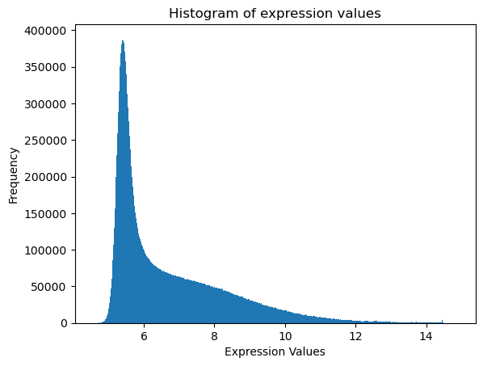

```python
data_cont_plt = data_cont.iloc[:, 2:].to_numpy().flatten() # pd to 1d array
# remove nan
data_cont_plt = data_cont_plt[~np.isnan(data_cont_plt)]

plt.hist(
    x = data_cont_plt,
    bins = 1000,
)
plt.ylabel("Frequency")
plt.xlabel("Expression Values")
plt.title("Histogram of expression values")
plt.show()
```

## Q2: Discrete Data (`data_mutations.txt`) - 15 pts

Now explore working with discrete variables using `data_mutations.txt`.

Read the data file into a data frame and display the first few rows

```python
!head -n3 brca_metabric/data_mutations.txt | tail -n2
#1. need to skip 1st line
#2. seems missing entrez_id

!head -n3 brca_metabric/data_mutations.txt | tail -n1 | hexdump -c
```

```
Hugo_Symbol	Entrez_Gene_Id	Center	NCBI_Build	Chromosome	Start_Position	End_Position	Strand	Consequence	Variant_Classification	Variant_Type	Reference_Allele	Tumor_Seq_Allele1	Tumor_Seq_Allele2	dbSNP_RS	dbSNP_Val_Status	Tumor_Sample_Barcode	Matched_Norm_Sample_Barcode	Match_Norm_Seq_Allele1	Match_Norm…
TP53		METABRIC	GRCh37	17	7579344	7579345	+	frameshift_variant	Frame_Shift_Ins	INS	-	-	G			MTS-T0058																Illumina HiSeq 2,000					ENST00000269305.4:c.343dup	p.His115ProfsTer34	p.H115Pfs*34	ENST00000269305	NM_001126112.2	114	-/C	0
0000000   T   P   5   3  \t  \t   M   E   T   A   B   R   I   C  \t   G
0000010   R   C   h   3   7  \t   1   7  \t   7   5   7   9   3   4   4
0000020  \t   7   5   7   9   3   4   5  \t   +  \t   f   r   a   m   e
0000030   s   h   i   f   t   _   v   a   r   i   a   n   t  \t   F   r
0000040   a   m   e   _   S   h   i   f   t   _   I   n   s  \t   I   N
0000050   S  \t   -  \t   -  \t   G  \t  \t  \t   M   T   S   -   T   0
0000060   0   5   8  \t  \t  \t  \t  \t  \t  \t  \t  \t  \t  \t  \t  \t
0000070  \t  \t  \t   I   l   l   u   m   i   n   a       H   i   S   e
0000080   q       2   ,   0   0   0  \t  \t  \t  \t  \t   E   N   S   T
0000090   0   0   0   0   0   2   6   9   3   0   5   .   4   :   c   .
00000a0   3   4   3   d   u   p  \t   p   .   H   i   s   1   1   5   P
00000b0   r   o   f   s   T   e   r   3   4  \t   p   .   H   1   1   5
00000c0   P   f   s   *   3   4  \t   E   N   S   T   0   0   0   0   0
00000d0   2   6   9   3   0   5  \t   N   M   _   0   0   1   1   2   6
00000e0   1   1   2   .   2  \t   1   1   4  \t   -   /   C  \t   0  \n
00000f0
```

```python
data_disc = pd.read_table("brca_metabric/data_mutations.txt",
                          skiprows=1,
                          sep = '\t', header=0)
```

```python
data_disc
```

|  | Hugo_Symbol | Entrez_Gene_Id | Center | NCBI_Build | Chromosome | Start_Position | End_Position | Strand | Consequence | Variant_Classification | ... | n_ref_count | n_alt_count | HGVSc | HGVSp | HGVSp_Short | Transcript_ID | RefSeq | Protein_position | Codons | Hotspot |
| --- | --- | --- | --- | --- | --- | --- | --- | --- | --- | --- | --- | --- | --- | --- | --- | --- | --- | --- | --- | --- | --- |
| 0 | TP53 | NaN | METABRIC | GRCh37 | 17 | 7579344 | 7579345 | + | frameshift_variant | Frame_Shift_Ins | ... | NaN | NaN | ENST00000269305.4:c.343dup | p.His115ProfsTer34 | p.H115Pfs*34 | ENST00000269305 | NM_001126112.2 | 114.0 | -/C | 0 |
| 1 | TP53 | NaN | METABRIC | GRCh37 | 17 | 7579346 | 7579347 | + | protein_altering_variant | In_Frame_Ins | ... | NaN | NaN | ENST00000269305.4:c.340_341insCTG | p.Leu114delinsSerVal | p.L114delinsSV | ENST00000269305 | NM_001126112.2 | 114.0 | ttg/tCTGtg | 0 |
| 2 | MLLT4 | NaN | METABRIC | GRCh37 | 6 | 168299111 | 168299111 | + | missense_variant | Missense_Mutation | ... | NaN | NaN | ENST00000392108.3:c.1544G>T | p.Gly515Val | p.G515V | ENST00000392108 | NM_001040000.2 | 515.0 | gGa/gTa | 0 |
| 3 | NF2 | NaN | METABRIC | GRCh37 | 22 | 29999995 | 29999995 | + | missense_variant | Missense_Mutation | ... | NaN | NaN | ENST00000338641.4:c.8G>T | p.Gly3Val | p.G3V | ENST00000338641 | NM_000268.3 | 3.0 | gGg/gTg | 0 |
| 4 | SF3B1 | NaN | METABRIC | GRCh37 | 2 | 198288682 | 198288682 | + | synonymous_variant | Silent | ... | NaN | NaN | ENST00000335508.6:c.45T>A | p.Ile15= | p.I15= | ENST00000335508 | NM_012433.2 | 15.0 | atT/atA | 0 |
| ... | ... | ... | ... | ... | ... | ... | ... | ... | ... | ... | ... | ... | ... | ... | ... | ... | ... | ... | ... | ... | ... |
| 17267 | PIK3CA | NaN | METABRIC | GRCh37 | 3 | 178917478 | 178917478 | + | missense_variant,splice_region_variant | Missense_Mutation | ... | NaN | NaN | ENST00000263967.3:c.353G>A | p.Gly118Asp | p.G118D | ENST00000263967 | NM_006218.2 | 118.0 | gGt/gAt | 0 |
| 17268 | PIK3CA | NaN | METABRIC | GRCh37 | 3 | 178952085 | 178952085 | + | missense_variant | Missense_Mutation | ... | NaN | NaN | ENST00000263967.3:c.3140A>G | p.His1047Arg | p.H1047R | ENST00000263967 | NM_006218.2 | 1047.0 | cAt/cGt | 0 |
| 17269 | TP53 | NaN | METABRIC | GRCh37 | 17 | 7579355 | 7579355 | + | missense_variant | Missense_Mutation | ... | NaN | NaN | ENST00000269305.4:c.332T>C | p.Leu111Pro | p.L111P | ENST00000269305 | NM_001126112.2 | 111.0 | cTg/cCg | 0 |
| 17270 | JAK1 | NaN | METABRIC | GRCh37 | 1 | 65311232 | 65311233 | + | frameshift_variant | Frame_Shift_Ins | ... | NaN | NaN | ENST00000342505.4:c.2079dup | p.Val694SerfsTer15 | p.V694Sfs*15 | ENST00000342505 | NM_002227.2 | 693.0 | aaa/aaAa | 0 |
| 17271 | DNAH11 | NaN | METABRIC | GRCh37 | 7 | 21627709 | 21627709 | + | missense_variant | Missense_Mutation | ... | NaN | NaN | ENST00000328843.6:c.1738G>C | p.Glu580Gln | p.E580Q | ENST00000328843 | NaN | 580.0 | Gag/Cag | 0 |

17272 rows × 45 columns

Print the number of rows and columns

```python
print('Rows: %d' % (data_disc.shape[0]))
print('Columns: %d' % (data_disc.shape[1]))
```

```
Rows: 17272
Columns: 45
```

What are the ten most frequently mutated genes and how frequently do they have a listed mutations?

```python
data_disc.columns
```

```
Index(['Hugo_Symbol', 'Entrez_Gene_Id', 'Center', 'NCBI_Build', 'Chromosome',
       'Start_Position', 'End_Position', 'Strand', 'Consequence',
       'Variant_Classification', 'Variant_Type', 'Reference_Allele',
       'Tumor_Seq_Allele1', 'Tumor_Seq_Allele2', 'dbSNP_RS',
       'dbSNP_Val_Status', 'Tumor_Sample_Barcode',
       'Matched_Norm_Sample_Barcode', 'Match_Norm_Seq_Allele1',
       'Match_Norm_Seq_Allele2', 'Tumor_Validation_Allele1',
       'Tumor_Validation_Allele2', 'Match_Norm_Validation_Allele1',
       'Match_Norm_Validation_Allele2', 'Verification_Status',
       'Validation_Status', 'Mutation_Status', 'Sequencing_Phase',
       'Sequence_Source', 'Validation_Method', 'Score', 'BAM_File',
       'Sequencer', 't_ref_count', 't_alt_count', 'n_ref_count', 'n_alt_count',
       'HGVSc', 'HGVSp', 'HGVSp_Short', 'Transcript_ID', 'RefSeq',
       'Protein_position', 'Codons', 'Hotspot'],
      dtype='object')
```

```python
Counter(data_disc['Hugo_Symbol']).most_common(10)
```

```
[('PIK3CA', 1122),
 ('TP53', 897),
 ('AHNAK2', 859),
 ('MUC16', 666),
 ('SYNE1', 468),
 ('KMT2C', 389),
 ('MAP3K1', 372),
 ('AHNAK', 327),
 ('GATA3', 301),
 ('DNAH11', 300)]
```

```python
data_disc['Hugo_Symbol'].value_counts()[:10]
```

```
Hugo_Symbol
PIK3CA    1122
TP53       897
AHNAK2     859
MUC16      666
SYNE1      468
KMT2C      389
MAP3K1     372
AHNAK      327
GATA3      301
DNAH11     300
Name: count, dtype: int64
```

What percentage of the records (rows) are for one of these ten genes?

```python
ls_top10 = data_disc['Hugo_Symbol'].value_counts()[:10].index.tolist()
pct_top10 = data_disc.query('Hugo_Symbol in @ls_top10').shape[0] / data_disc.shape[0]
print('Top 10 percentage: %.2f%%' % (pct_top10*100))
```

```
Top 10 percentage: 33.01%
```

Now, we will look at the discrete variable `Consequence` which represents the variant type.

Plot the frequency of each unique value (histogram)

TVL Comment: Maybe using bar plot??

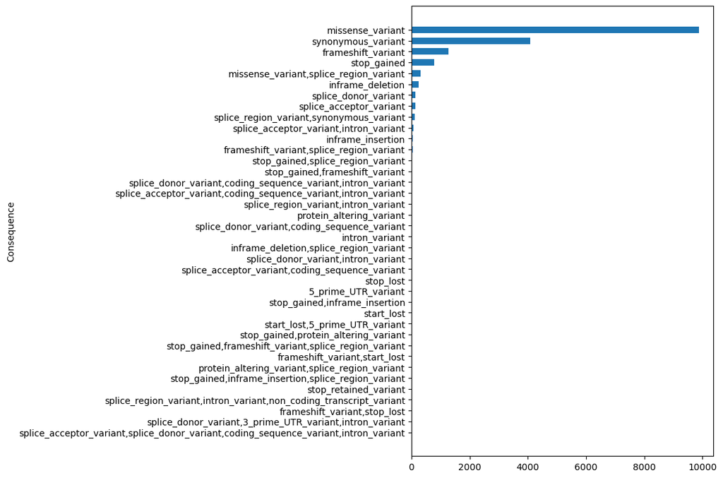

```python
df_plt_conseq = pd.DataFrame({
    "Consequence": Counter(data_disc['Consequence']).keys(),
    "Frequency": Counter(data_disc['Consequence']).values(),
}).sort_values(by = "Frequency", ascending=True)
# print(df_plt_conseq)

plt.figure(figsize=(6, 9))  # taller figure
plt.barh(y = df_plt_conseq['Consequence'], width = df_plt_conseq['Frequency'], height=0.6)
plt.ylabel('Consequence')
plt.show()
```

# TCGA Breast Invasive Carcinoma Dataset (55 points)

Now, download and unpack the dataset at https://cbioportal-datahub.s3.amazonaws.com/brca_tcga.tar.gz. We will be focusing on only two files from here now, `data_mrna_seq_v2_rsem.txt`, containing expression values as before and `data_mutations.txt`, containing information on mutated genes.

**Repeat all the questions for this new dataset and display your results in a notebook.**

*Switched to cluster here*

```python
!wget https://datahub.assets.cbioportal.org/brca_tcga.tar.gz
```

```
--2026-01-20 20:05:15--  https://datahub.assets.cbioportal.org/brca_tcga.tar.gz
Resolving datahub.assets.cbioportal.org (datahub.assets.cbioportal.org)... 2600:9000:2508:c00:1a:8960:1bc0:93a1, 2600:9000:2508:bc00:1a:8960:1bc0:93a1, 2600:9000:2508:ac00:1a:8960:1bc0:93a1, ...
Connecting to datahub.assets.cbioportal.org (datahub.assets.cbioportal.org)|2600:9000:2508:c00:1a:8960:1bc0:93a1|:443... connected.
HTTP request sent, awaiting response... 200 OK
Length: 407682488 (389M) [application/x-tar]
Saving to: ‘brca_tcga.tar.gz’

brca_tcga.tar.gz    100%[===================>] 388.80M  44.2MB/s    in 9.8s

2026-01-20 20:05:25 (39.8 MB/s) - ‘brca_tcga.tar.gz’ saved [407682488/407682488]
```

```python
!tar -xzvf brca_tcga.tar.gz
```

```
brca_tcga/
brca_tcga/data_mutsig.txt
brca_tcga/data_clinical_sample.txt
brca_tcga/data_phosphoprotein_quantification.txt
brca_tcga/meta_study.txt
brca_tcga/meta_mrna_seq_v2_rsem.txt
brca_tcga/meta_mrna_agilent_microarray_zscores_ref_diploid_samples.txt
brca_tcga/LICENSE
brca_tcga/data_gistic_genes_amp.txt
brca_tcga/data_mrna_agilent_microarray_zscores_ref_diploid_samples.txt
brca_tcga/data_linear_cna.txt
brca_tcga/data_gistic_genes_del.txt
brca_tcga/meta_mrna_agilent_microarray.txt
brca_tcga/meta_methylation_hm450.txt
brca_tcga/meta_clinical_patient.txt
brca_tcga/meta_cna_hg19_seg.txt
brca_tcga/meta_mutsig.txt
brca_tcga/meta_linear_cna.txt
brca_tcga/data_mrna_agilent_microarray_zscores_ref_all_samples.txt
brca_tcga/data_mrna_seq_v2_rsem_zscores_ref_diploid_samples.txt
brca_tcga/case_lists/
brca_tcga/case_lists/cases_RNA_Seq_v2_mRNA.txt
brca_tcga/case_lists/cases_protein_quantification.txt
brca_tcga/case_lists/cases_all.txt
brca_tcga/case_lists/cases_methylation_all.txt
brca_tcga/case_lists/cases_phosphoprotein_quantification.txt
brca_tcga/case_lists/cases_rppa.txt
brca_tcga/case_lists/cases_complete.txt
brca_tcga/case_lists/cases_mRNA.txt
brca_tcga/case_lists/cases_methylation_hm450.txt
brca_tcga/case_lists/cases_cnaseq.txt
brca_tcga/case_lists/cases_cna.txt
brca_tcga/case_lists/cases_sequenced.txt
brca_tcga/case_lists/cases_methylation_hm27.txt
brca_tcga/meta_clinical_sample.txt
brca_tcga/data_mutations.txt
brca_tcga/meta_protein_quantification.txt
brca_tcga/data_cna.txt
brca_tcga/meta_mrna_seq_v2_rsem_zscores_ref_all_samples.txt
brca_tcga/data_mrna_seq_v2_rsem_zscores_ref_all_samples.txt
brca_tcga/meta_protein_quantification_zscores.txt
brca_tcga/meta_mrna_agilent_microarray_zscores_ref_all_samples.txt
brca_tcga/meta_mrna_seq_v2_rsem_zscores_ref_diploid_samples.txt
brca_tcga/meta_rppa.txt
brca_tcga/data_rppa_zscores.txt
brca_tcga/data_mrna_seq_v2_rsem.txt
brca_tcga/data_rppa.txt
brca_tcga/data_clinical_patient.txt
brca_tcga/meta_mutations.txt
brca_tcga/meta_rppa_zscores.txt
brca_tcga/data_protein_quantification_zscores.txt
brca_tcga/meta_phosphoprotein_quantification.txt
brca_tcga/data_mrna_agilent_microarray.txt
brca_tcga/meta_gistic_genes_del.txt
brca_tcga/data_protein_quantification.txt
brca_tcga/data_methylation_hm450.txt
brca_tcga/meta_cna.txt
brca_tcga/meta_gistic_genes_amp.txt
brca_tcga/data_cna_hg19.seg
```

```python
!ls -la brca_tcga
```

```
total 1329916
drwxr-xr-x 2 til177 hpark      4096 Dec 26  2024 .
drwxr-xr-x 2 til177 hpark      4096 Jan 20 23:02 ..
drwxr-xr-x 2 til177 hpark      4096 Dec 26  2024 case_lists
-rw-r--r-- 1 til177 hpark   1703839 Dec 26  2024 data_clinical_patient.txt
-rw-r--r-- 1 til177 hpark    459870 Dec 26  2024 data_clinical_sample.txt
-rw-r--r-- 1 til177 hpark  10380570 Dec 26  2024 data_cna_hg19.seg
-rw-r--r-- 1 til177 hpark  60055391 Dec 26  2024 data_cna.txt
-rw-r--r-- 1 til177 hpark      8705 Dec 26  2024 data_gistic_genes_amp.txt
-rw-r--r-- 1 til177 hpark     27718 Dec 26  2024 data_gistic_genes_del.txt
-rw-r--r-- 1 til177 hpark 173709974 Dec 26  2024 data_linear_cna.txt
-rw-r--r-- 1 til177 hpark 236865655 Dec 26  2024 data_methylation_hm450.txt
-rw-r--r-- 1 til177 hpark  94564954 Dec 26  2024 data_mrna_agilent_microarray.txt
-rw-r--r-- 1 til177 hpark  71020043 Dec 26  2024 data_mrna_agilent_microarray_zscores_ref_all_samples.txt
-rw-r--r-- 1 til177 hpark  65524999 Dec 26  2024 data_mrna_agilent_microarray_zscores_ref_diploid_samples.txt
-rw-r--r-- 1 til177 hpark 192450890 Dec 26  2024 data_mrna_seq_v2_rsem.txt
-rw-r--r-- 1 til177 hpark 167283509 Dec 26  2024 data_mrna_seq_v2_rsem_zscores_ref_all_samples.txt
-rw-r--r-- 1 til177 hpark 162354859 Dec 26  2024 data_mrna_seq_v2_rsem_zscores_ref_diploid_samples.txt
-rw-r--r-- 1 til177 hpark  55933694 Dec 26  2024 data_mutations.txt
-rw-r--r-- 1 til177 hpark   1988307 Dec 26  2024 data_mutsig.txt
-rw-r--r-- 1 til177 hpark  44037202 Dec 26  2024 data_phosphoprotein_quantification.txt
-rw-r--r-- 1 til177 hpark  14537298 Dec 26  2024 data_protein_quantification.txt
-rw-r--r-- 1 til177 hpark   5753216 Dec 26  2024 data_protein_quantification_zscores.txt
-rw-r--r-- 1 til177 hpark   1721157 Dec 26  2024 data_rppa.txt
-rw-r--r-- 1 til177 hpark   1432604 Dec 26  2024 data_rppa_zscores.txt
-rw-r--r-- 1 til177 hpark       446 Dec 26  2024 LICENSE
-rw-r--r-- 1 til177 hpark       139 Dec 26  2024 meta_clinical_patient.txt
-rw-r--r-- 1 til177 hpark       137 Dec 26  2024 meta_clinical_sample.txt
-rw-r--r-- 1 til177 hpark       269 Dec 26  2024 meta_cna_hg19_seg.txt
-rw-r--r-- 1 til177 hpark       458 Dec 26  2024 meta_cna.txt
-rw-r--r-- 1 til177 hpark       162 Dec 26  2024 meta_gistic_genes_amp.txt
-rw-r--r-- 1 til177 hpark       162 Dec 26  2024 meta_gistic_genes_del.txt
-rw-r--r-- 1 til177 hpark       354 Dec 26  2024 meta_linear_cna.txt
-rw-r--r-- 1 til177 hpark       403 Dec 26  2024 meta_methylation_hm450.txt
-rw-r--r-- 1 til177 hpark       335 Dec 26  2024 meta_mrna_agilent_microarray.txt
-rw-r--r-- 1 til177 hpark       463 Dec 26  2024 meta_mrna_agilent_microarray_zscores_ref_all_samples.txt
-rw-r--r-- 1 til177 hpark       475 Dec 26  2024 meta_mrna_agilent_microarray_zscores_ref_diploid_samples.txt
-rw-r--r-- 1 til177 hpark       309 Dec 26  2024 meta_mrna_seq_v2_rsem.txt
-rw-r--r-- 1 til177 hpark       468 Dec 26  2024 meta_mrna_seq_v2_rsem_zscores_ref_all_samples.txt
-rw-r--r-- 1 til177 hpark       481 Dec 26  2024 meta_mrna_seq_v2_rsem_zscores_ref_diploid_samples.txt
-rw-r--r-- 1 til177 hpark       387 Dec 26  2024 meta_mutations.txt
-rw-r--r-- 1 til177 hpark       142 Dec 26  2024 meta_mutsig.txt
-rw-r--r-- 1 til177 hpark       610 Dec 26  2024 meta_phosphoprotein_quantification.txt
-rw-r--r-- 1 til177 hpark       398 Dec 26  2024 meta_protein_quantification.txt
-rw-r--r-- 1 til177 hpark       426 Dec 26  2024 meta_protein_quantification_zscores.txt
-rw-r--r-- 1 til177 hpark       296 Dec 26  2024 meta_rppa.txt
-rw-r--r-- 1 til177 hpark       328 Dec 26  2024 meta_rppa_zscores.txt
-rw-r--r-- 1 til177 hpark       357 Dec 26  2024 meta_study.txt
```

### Q1: Continuous values

Read the data file into a data frame

```python
data2_cont = pd.read_table('brca_tcga/data_mrna_seq_v2_rsem.txt', header=0)
```

Display a portion of the data to get a feel for the dataset

```python
data2_cont
```

|  | Hugo_Symbol | Entrez_Gene_Id | TCGA-3C-AAAU-01 | TCGA-3C-AALI-01 | TCGA-3C-AALJ-01 | TCGA-3C-AALK-01 | TCGA-4H-AAAK-01 | TCGA-5L-AAT0-01 | TCGA-5L-AAT1-01 | TCGA-5T-A9QA-01 | ... | TCGA-UL-AAZ6-01 | TCGA-UU-A93S-01 | TCGA-V7-A7HQ-01 | TCGA-W8-A86G-01 | TCGA-WT-AB41-01 | TCGA-WT-AB44-01 | TCGA-XX-A899-01 | TCGA-XX-A89A-01 | TCGA-Z7-A8R5-01 | TCGA-Z7-A8R6-01 |
| --- | --- | --- | --- | --- | --- | --- | --- | --- | --- | --- | --- | --- | --- | --- | --- | --- | --- | --- | --- | --- | --- |
| 0 | LOC100130426 | 100130426 | 0.0000 | 0.0000 | 0.9066 | 0.0000 | 0.0000 | 0.0000 | 0.0000 | 0.0000 | ... | 0.0000 | 0.0000 | 0.0000 | 0.0000 | 0.0000 | 0.0000 | 0.0000 | 0.0000 | 0.0000 | 0.0000 |
| 1 | UBE2Q2P3 | 100133144 | 16.3644 | 9.2659 | 11.6228 | 12.0894 | 6.8468 | 3.9889 | 0.0000 | 1.4644 | ... | 0.3992 | 4.3126 | 0.0000 | 5.5624 | 0.0000 | 0.0000 | 14.3858 | 22.3240 | 2.2638 | 6.8865 |
| 2 | UBE2Q2P3 | 100134869 | 12.9316 | 17.3790 | 9.2294 | 11.0799 | 14.4298 | 13.6090 | 10.5949 | 8.9958 | ... | 14.3720 | 10.8828 | 3.0792 | 14.3711 | 6.3091 | 3.2580 | 21.4409 | 27.2744 | 7.2933 | 24.7795 |
| 3 | HMGB1P1 | 10357 | 52.1503 | 69.7553 | 154.2974 | 143.8643 | 84.2128 | 114.2572 | 115.9984 | 107.5628 | ... | 135.6241 | 136.1288 | 29.9974 | 128.3151 | 53.6278 | 42.2643 | 137.7756 | 64.1427 | 85.0461 | 167.5511 |
| 4 | TIMM23 | 10431 | 408.0760 | 563.8934 | 1360.8341 | 865.5358 | 766.3830 | 807.7431 | 1108.3945 | 1420.5021 | ... | 1570.1445 | 2886.3965 | 1721.8816 | 697.6744 | 1245.2681 | 1877.4180 | 652.7559 | 722.7208 | 1140.2801 | 1003.5668 |
| ... | ... | ... | ... | ... | ... | ... | ... | ... | ... | ... | ... | ... | ... | ... | ... | ... | ... | ... | ... | ... | ... |
| 20526 | ZYX | 7791 | 3507.2482 | 5504.6221 | 5458.7489 | 5691.3529 | 4041.7021 | 4131.9842 | 4418.0929 | 3221.7573 | ... | 4163.4978 | 5594.0666 | 6453.3611 | 5550.5458 | 6675.8675 | 10937.0800 | 5118.1102 | 5477.5626 | 6675.6264 | 3402.5228 |
| 20527 | FLJ10821 | 23140 | 1894.9342 | 1318.6514 | 942.8830 | 781.1336 | 831.9149 | 922.1293 | 1411.5729 | 1115.0628 | ... | 1242.3823 | 538.3502 | 747.6267 | 970.0997 | 558.3596 | 800.6516 | 1933.8583 | 1437.4114 | 754.4127 | 564.4193 |
| 20528 | ZZZ3 | 26009 | 1180.4565 | 406.7428 | 509.5195 | 700.8688 | 881.7021 | 1061.7393 | 568.8672 | 440.8996 | ... | 310.5956 | 386.3965 | 303.6079 | 870.9065 | 287.0662 | 443.0869 | 670.0787 | 953.7081 | 750.8288 | 462.1140 |
| 20529 | TPTEP1 | 387590 | 1.7233 | 926.5905 | 35.3581 | 66.6115 | 187.2340 | 85.0565 | 57.8647 | 3.6611 | ... | 10.7790 | 7.2359 | 286.9803 | 220.2183 | 28.3912 | 724.9033 | 98.4252 | 235.2385 | 238.9272 | 20.8786 |
| 20530 | AKR1C6P | 389932 | 0.0000 | 0.0000 | 0.0000 | 0.0000 | 0.0000 | 0.0000 | 0.0000 | 0.0000 | ... | 0.0000 | 0.0000 | 0.0000 | 0.0000 | 0.0000 | 0.0000 | 0.0000 | 0.9447 | 0.0000 | 0.0000 |

20531 rows × 1102 columns

```python
display(data2_cont.head())
display(data2_cont.tail())
```

|  | Hugo_Symbol | Entrez_Gene_Id | TCGA-3C-AAAU-01 | TCGA-3C-AALI-01 | TCGA-3C-AALJ-01 | TCGA-3C-AALK-01 | TCGA-4H-AAAK-01 | TCGA-5L-AAT0-01 | TCGA-5L-AAT1-01 | TCGA-5T-A9QA-01 | ... | TCGA-UL-AAZ6-01 | TCGA-UU-A93S-01 | TCGA-V7-A7HQ-01 | TCGA-W8-A86G-01 | TCGA-WT-AB41-01 | TCGA-WT-AB44-01 | TCGA-XX-A899-01 | TCGA-XX-A89A-01 | TCGA-Z7-A8R5-01 | TCGA-Z7-A8R6-01 |
| --- | --- | --- | --- | --- | --- | --- | --- | --- | --- | --- | --- | --- | --- | --- | --- | --- | --- | --- | --- | --- | --- |
| 0 | LOC100130426 | 100130426 | 0.0000 | 0.0000 | 0.9066 | 0.0000 | 0.0000 | 0.0000 | 0.0000 | 0.0000 | ... | 0.0000 | 0.0000 | 0.0000 | 0.0000 | 0.0000 | 0.0000 | 0.0000 | 0.0000 | 0.0000 | 0.0000 |
| 1 | UBE2Q2P3 | 100133144 | 16.3644 | 9.2659 | 11.6228 | 12.0894 | 6.8468 | 3.9889 | 0.0000 | 1.4644 | ... | 0.3992 | 4.3126 | 0.0000 | 5.5624 | 0.0000 | 0.0000 | 14.3858 | 22.3240 | 2.2638 | 6.8865 |
| 2 | UBE2Q2P3 | 100134869 | 12.9316 | 17.3790 | 9.2294 | 11.0799 | 14.4298 | 13.6090 | 10.5949 | 8.9958 | ... | 14.3720 | 10.8828 | 3.0792 | 14.3711 | 6.3091 | 3.2580 | 21.4409 | 27.2744 | 7.2933 | 24.7795 |
| 3 | HMGB1P1 | 10357 | 52.1503 | 69.7553 | 154.2974 | 143.8643 | 84.2128 | 114.2572 | 115.9984 | 107.5628 | ... | 135.6241 | 136.1288 | 29.9974 | 128.3151 | 53.6278 | 42.2643 | 137.7756 | 64.1427 | 85.0461 | 167.5511 |
| 4 | TIMM23 | 10431 | 408.0760 | 563.8934 | 1360.8341 | 865.5358 | 766.3830 | 807.7431 | 1108.3945 | 1420.5021 | ... | 1570.1445 | 2886.3965 | 1721.8816 | 697.6744 | 1245.2681 | 1877.4180 | 652.7559 | 722.7208 | 1140.2801 | 1003.5668 |

5 rows × 1102 columns

|  | Hugo_Symbol | Entrez_Gene_Id | TCGA-3C-AAAU-01 | TCGA-3C-AALI-01 | TCGA-3C-AALJ-01 | TCGA-3C-AALK-01 | TCGA-4H-AAAK-01 | TCGA-5L-AAT0-01 | TCGA-5L-AAT1-01 | TCGA-5T-A9QA-01 | ... | TCGA-UL-AAZ6-01 | TCGA-UU-A93S-01 | TCGA-V7-A7HQ-01 | TCGA-W8-A86G-01 | TCGA-WT-AB41-01 | TCGA-WT-AB44-01 | TCGA-XX-A899-01 | TCGA-XX-A89A-01 | TCGA-Z7-A8R5-01 | TCGA-Z7-A8R6-01 |
| --- | --- | --- | --- | --- | --- | --- | --- | --- | --- | --- | --- | --- | --- | --- | --- | --- | --- | --- | --- | --- | --- |
| 20526 | ZYX | 7791 | 3507.2482 | 5504.6221 | 5458.7489 | 5691.3529 | 4041.7021 | 4131.9842 | 4418.0929 | 3221.7573 | ... | 4163.4978 | 5594.0666 | 6453.3611 | 5550.5458 | 6675.8675 | 10937.0800 | 5118.1102 | 5477.5626 | 6675.6264 | 3402.5228 |
| 20527 | FLJ10821 | 23140 | 1894.9342 | 1318.6514 | 942.8830 | 781.1336 | 831.9149 | 922.1293 | 1411.5729 | 1115.0628 | ... | 1242.3823 | 538.3502 | 747.6267 | 970.0997 | 558.3596 | 800.6516 | 1933.8583 | 1437.4114 | 754.4127 | 564.4193 |
| 20528 | ZZZ3 | 26009 | 1180.4565 | 406.7428 | 509.5195 | 700.8688 | 881.7021 | 1061.7393 | 568.8672 | 440.8996 | ... | 310.5956 | 386.3965 | 303.6079 | 870.9065 | 287.0662 | 443.0869 | 670.0787 | 953.7081 | 750.8288 | 462.1140 |
| 20529 | TPTEP1 | 387590 | 1.7233 | 926.5905 | 35.3581 | 66.6115 | 187.2340 | 85.0565 | 57.8647 | 3.6611 | ... | 10.7790 | 7.2359 | 286.9803 | 220.2183 | 28.3912 | 724.9033 | 98.4252 | 235.2385 | 238.9272 | 20.8786 |
| 20530 | AKR1C6P | 389932 | 0.0000 | 0.0000 | 0.0000 | 0.0000 | 0.0000 | 0.0000 | 0.0000 | 0.0000 | ... | 0.0000 | 0.0000 | 0.0000 | 0.0000 | 0.0000 | 0.0000 | 0.0000 | 0.9447 | 0.0000 | 0.0000 |

5 rows × 1102 columns

```python
data2_cont.shape
```

```
(20531, 1102)
```

Print the number of records (rows)

```python
print('Number of records/genes: %d' % data2_cont.shape[0])
```

```
Number of records/genes: 20531
```

Print the number of variables (columns)

```python
print('Number of columns/variables: %d' % data2_cont.shape[1])
```

```
Number of columns/variables: 1102
```

Print the number of missing entries in the data

```python
(data2_cont.isna()
          .sum() #by col
          .sum() #1d
)
```

```
1
```

```python
print('Number of missing values in the data: %d' % (data2_cont.isna().sum().sum()) )
```

```
Number of missing values in the data: 1
```

Print the genes (Hugo_Symbol) and columns with missing values.

```python
print(np.where(data2_cont.isna()))
print()

print(data2_cont.iloc[19672,:]) #Hugo_Symbol is NA
```

```
(array([19672]), array([0]))

Hugo_Symbol             NaN
Entrez_Gene_Id         7504
TCGA-3C-AAAU-01    279.1736
TCGA-3C-AALI-01    173.4638
TCGA-3C-AALJ-01     60.7434
                     ...
TCGA-WT-AB44-01       4.887
TCGA-XX-A899-01     10.2362
TCGA-XX-A89A-01     12.7539
TCGA-Z7-A8R5-01     16.1276
TCGA-Z7-A8R6-01      16.007
Name: 19672, Length: 1102, dtype: object
```

```python
# get indices of nans
idx = np.where(data2_cont.isna()) #input boolean
# print(len(idx))

# convert the tuple to a dictionary for structured output (same as the answer format)
dict_genes = defaultdict(list)
for id in range(len(idx[0])):
    # print(id)
    row = idx[0][id]
    col = idx[1][id]
    # Get correspondign gene anme and colname
    geneName = data2_cont['Hugo_Symbol'][row]
    colName  = data2_cont.columns[col]
    # Store the same gene name together as a list
    dict_genes[geneName].append(colName)

print(dict_genes)
print()

for gene, cols in dict_genes.items():
    print(f'{gene}: {" ".join(dict_genes[gene])}')
```

```
defaultdict(<class 'list'>, {nan: ['Hugo_Symbol']})

nan: Hugo_Symbol
```

Calculate the mean, variance, min, and max over **all** the expression values in the dataset

```python
display(data2_cont)
data2_cont.dtypes[data2_cont.dtypes != "float64"]
```

|  | Hugo_Symbol | Entrez_Gene_Id | TCGA-3C-AAAU-01 | TCGA-3C-AALI-01 | TCGA-3C-AALJ-01 | TCGA-3C-AALK-01 | TCGA-4H-AAAK-01 | TCGA-5L-AAT0-01 | TCGA-5L-AAT1-01 | TCGA-5T-A9QA-01 | ... | TCGA-UL-AAZ6-01 | TCGA-UU-A93S-01 | TCGA-V7-A7HQ-01 | TCGA-W8-A86G-01 | TCGA-WT-AB41-01 | TCGA-WT-AB44-01 | TCGA-XX-A899-01 | TCGA-XX-A89A-01 | TCGA-Z7-A8R5-01 | TCGA-Z7-A8R6-01 |
| --- | --- | --- | --- | --- | --- | --- | --- | --- | --- | --- | --- | --- | --- | --- | --- | --- | --- | --- | --- | --- | --- |
| 0 | LOC100130426 | 100130426 | 0.0000 | 0.0000 | 0.9066 | 0.0000 | 0.0000 | 0.0000 | 0.0000 | 0.0000 | ... | 0.0000 | 0.0000 | 0.0000 | 0.0000 | 0.0000 | 0.0000 | 0.0000 | 0.0000 | 0.0000 | 0.0000 |
| 1 | UBE2Q2P3 | 100133144 | 16.3644 | 9.2659 | 11.6228 | 12.0894 | 6.8468 | 3.9889 | 0.0000 | 1.4644 | ... | 0.3992 | 4.3126 | 0.0000 | 5.5624 | 0.0000 | 0.0000 | 14.3858 | 22.3240 | 2.2638 | 6.8865 |
| 2 | UBE2Q2P3 | 100134869 | 12.9316 | 17.3790 | 9.2294 | 11.0799 | 14.4298 | 13.6090 | 10.5949 | 8.9958 | ... | 14.3720 | 10.8828 | 3.0792 | 14.3711 | 6.3091 | 3.2580 | 21.4409 | 27.2744 | 7.2933 | 24.7795 |
| 3 | HMGB1P1 | 10357 | 52.1503 | 69.7553 | 154.2974 | 143.8643 | 84.2128 | 114.2572 | 115.9984 | 107.5628 | ... | 135.6241 | 136.1288 | 29.9974 | 128.3151 | 53.6278 | 42.2643 | 137.7756 | 64.1427 | 85.0461 | 167.5511 |
| 4 | TIMM23 | 10431 | 408.0760 | 563.8934 | 1360.8341 | 865.5358 | 766.3830 | 807.7431 | 1108.3945 | 1420.5021 | ... | 1570.1445 | 2886.3965 | 1721.8816 | 697.6744 | 1245.2681 | 1877.4180 | 652.7559 | 722.7208 | 1140.2801 | 1003.5668 |
| ... | ... | ... | ... | ... | ... | ... | ... | ... | ... | ... | ... | ... | ... | ... | ... | ... | ... | ... | ... | ... | ... |
| 20526 | ZYX | 7791 | 3507.2482 | 5504.6221 | 5458.7489 | 5691.3529 | 4041.7021 | 4131.9842 | 4418.0929 | 3221.7573 | ... | 4163.4978 | 5594.0666 | 6453.3611 | 5550.5458 | 6675.8675 | 10937.0800 | 5118.1102 | 5477.5626 | 6675.6264 | 3402.5228 |
| 20527 | FLJ10821 | 23140 | 1894.9342 | 1318.6514 | 942.8830 | 781.1336 | 831.9149 | 922.1293 | 1411.5729 | 1115.0628 | ... | 1242.3823 | 538.3502 | 747.6267 | 970.0997 | 558.3596 | 800.6516 | 1933.8583 | 1437.4114 | 754.4127 | 564.4193 |
| 20528 | ZZZ3 | 26009 | 1180.4565 | 406.7428 | 509.5195 | 700.8688 | 881.7021 | 1061.7393 | 568.8672 | 440.8996 | ... | 310.5956 | 386.3965 | 303.6079 | 870.9065 | 287.0662 | 443.0869 | 670.0787 | 953.7081 | 750.8288 | 462.1140 |
| 20529 | TPTEP1 | 387590 | 1.7233 | 926.5905 | 35.3581 | 66.6115 | 187.2340 | 85.0565 | 57.8647 | 3.6611 | ... | 10.7790 | 7.2359 | 286.9803 | 220.2183 | 28.3912 | 724.9033 | 98.4252 | 235.2385 | 238.9272 | 20.8786 |
| 20530 | AKR1C6P | 389932 | 0.0000 | 0.0000 | 0.0000 | 0.0000 | 0.0000 | 0.0000 | 0.0000 | 0.0000 | ... | 0.0000 | 0.0000 | 0.0000 | 0.0000 | 0.0000 | 0.0000 | 0.0000 | 0.9447 | 0.0000 | 0.0000 |

20531 rows × 1102 columns

```
Hugo_Symbol       object
Entrez_Gene_Id     int64
dtype: object
```

```python
# This is to replicate the answer
print(
'''
Mean: %.3f
Variance: %.3f
Minimum: %.3f
Maximum: %.3f
''' % (data2_cont.iloc[:, 2:].mean().mean(),
        data2_cont.iloc[:, 2:].var().mean(),
        data2_cont.iloc[:, 2:].min().min(),
        data2_cont.iloc[:, 2:].max().max()
        )
)
```

```
Mean: 935.099
Variance: 19297162.268
Minimum: 0.000
Maximum: 2066039.163
```

Plot the histogram for all expression values using a sufficient number of bins that the shape of the data is clear. You may need to [clip](https://numpy.org/doc/stable/reference/generated/numpy.clip.html) outliers from the data so the distribution is clear (hint: this will be the case for the next section).

```
0.0
-7205.4514336209695 9075.64867953792
```

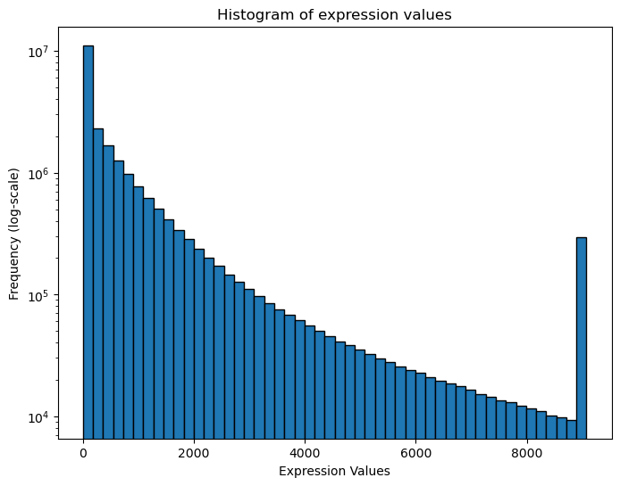

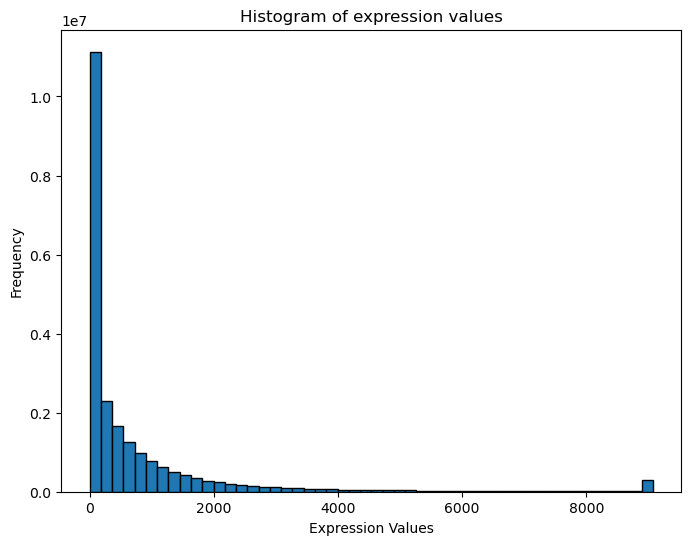

```python
data2_cont_plt = data2_cont.iloc[:, 2:].to_numpy().flatten() # pd to 1d array
print(data2_cont_plt[np.isnan(data2_cont_plt)].sum())
# # remove nan
# data2_cont_plt = data2_cont_plt[~np.isnan(data2_cont_plt)]

# Clip outliers by mean+/-2std
mean = data2_cont.iloc[:, 2:].mean().mean()
std = data2_cont.iloc[:, 2:].std().mean()
print(mean-2*std, mean+2*std)
data2_cont_plt_clipped = np.clip(data2_cont_plt, a_min = mean - 2*std, a_max=mean + 2*std)

# Plot
plt.figure(figsize=(8, 6))
plt.hist(
    x = data2_cont_plt_clipped,
    bins = 50,
    edgecolor='black'
)
plt.ylabel("Frequency (log-scale)"); plt.yscale('log')
plt.xlabel("Expression Values")
plt.title("Histogram of expression values")
plt.show()

plt.figure(figsize=(8, 6))
plt.hist(
    x = data2_cont_plt_clipped,
    bins = 50,
    edgecolor='black'
)
plt.ylabel("Frequency")
plt.xlabel("Expression Values")
plt.title("Histogram of expression values")
plt.show()
```

## Q2: Discrete Data (`data_mutations.txt`)

Now explore working with discrete variables using `data_mutations.txt`.

Read the data file into a data frame and display the first few rows

```python
!head -n2 brca_tcga/data_mutations.txt
!head -n2 brca_tcga/data_mutations.txt | tail -n1 | hexdump -c
```

```
Hugo_Symbol	Entrez_Gene_Id	Center	NCBI_Build	Chromosome	Start_Position	End_Position	Strand	Consequence	Variant_Classification	Variant_Type	Reference_Allele	Tumor_Seq_Allele1	Tumor_Seq_Allele2	dbSNP_RS	dbSNP_Val_Status	Tumor_Sample_Barcode	Matched_Norm_Sample_Barcode	Match_Norm_Seq_Allele1	Match_Norm…
ACPP	55	genome.wustl.edu	GRCh37	3	132047117	132047117	+	missense_variant	Missense_Mutation	SNP	C	C	T			TCGA-AR-A24X-01	TCGA-AR-A24X-10	C	C					Unknown	Untested	Somatic	Phase_IV	WXS	none	1	dbGAP	Illumina GAIIx	17	7			ENST00000351273.7:c.127C>T	p.Arg43Trp	p.R43W	ENST00000351273	NM_001134194.1	43	Cgg/T…
0000000   A   C   P   P  \t   5   5  \t   g   e   n   o   m   e   .   w
0000010   u   s   t   l   .   e   d   u  \t   G   R   C   h   3   7  \t
0000020   3  \t   1   3   2   0   4   7   1   1   7  \t   1   3   2   0
0000030   4   7   1   1   7  \t   +  \t   m   i   s   s   e   n   s   e
0000040   _   v   a   r   i   a   n   t  \t   M   i   s   s   e   n   s
0000050   e   _   M   u   t   a   t   i   o   n  \t   S   N   P  \t   C
0000060  \t   C  \t   T  \t  \t  \t   T   C   G   A   -   A   R   -   A
0000070   2   4   X   -   0   1  \t   T   C   G   A   -   A   R   -   A
0000080   2   4   X   -   1   0  \t   C  \t   C  \t  \t  \t  \t  \t   U
0000090   n   k   n   o   w   n  \t   U   n   t   e   s   t   e   d  \t
00000a0   S   o   m   a   t   i   c  \t   P   h   a   s   e   _   I   V
00000b0  \t   W   X   S  \t   n   o   n   e  \t   1  \t   d   b   G   A
00000c0   P  \t   I   l   l   u   m   i   n   a       G   A   I   I   x
00000d0  \t   1   7  \t   7  \t  \t  \t   E   N   S   T   0   0   0   0
00000e0   0   3   5   1   2   7   3   .   7   :   c   .   1   2   7   C
00000f0   >   T  \t   p   .   A   r   g   4   3   T   r   p  \t   p   .
0000100   R   4   3   W  \t   E   N   S   T   0   0   0   0   0   3   5
0000110   1   2   7   3  \t   N   M   _   0   0   1   1   3   4   1   9
0000120   4   .   1  \t   4   3  \t   C   g   g   /   T   g   g  \t   0
0000130  \t   e   n   s   e   m   b   l  \t   -  \t   k   n   o   w   n
0000140  \t   1   3   2   0   4   7   1   1   7  \t   1  \t   -  \t   h
0000150   u   m   a   n  \t   A   C   P   P  \t   2   9   .   1   7  \t
0000160   -  \t   A   C   P   P  \t   T  \t   2   0  \t   S   N   P  \t
0000170   1   3   2   0   4   7   1   1   7  \t   p   .   R   4   3   W
0000180  \t   1  \t   c   .   1   2   7  \t   p   f   a   m   _   H   i
0000190   s   _   P   a   s   e   _   s   u   p   e   r   F   _   c   l
00001a0   a   d   e   -   2  \t   7  \t   E   N   S   T   0   0   0   0
00001b0   0   3   5   1   2   7   3  \t   E   N   S   G   0   0   0   0
00001c0   0   0   1   4   2   5   7  \t   C  \t   -  \t   p   f   a   m
00001d0   _   H   i   s   _   P   a   s   e   _   s   u   p   e   r   F
00001e0   _   c   l   a   d   e   -   2  \t   H   G   N   C  \t   m   i
00001f0   s   s   e   n   s   e  \t   n   o   _   e   r   r   o   r   s
0000200  \t   0  \t   1   7  \t   6   9   _   3   7   n  \t   0  \t   3
0000210  \n
0000211
```

```python
data2_disc = pd.read_table("brca_tcga/data_mutations.txt",
                          sep = '\t', header=0)
```

```python
data2_disc
```

|  | Hugo_Symbol | Entrez_Gene_Id | Center | NCBI_Build | Chromosome | Start_Position | End_Position | Strand | Consequence | Variant_Classification | ... | deletion_substructures_WU | domain_WU | gene_name_source_WU | trv_type_WU | transcript_error_WU | normal_vaf | tumor_ref_reads | transcript_version_WU | normal_var_reads | chromosome_name_WU |
| --- | --- | --- | --- | --- | --- | --- | --- | --- | --- | --- | --- | --- | --- | --- | --- | --- | --- | --- | --- | --- | --- |
| 0 | ACPP | 55.0 | genome.wustl.edu | GRCh37 | 3 | 132047117 | 132047117 | + | missense_variant | Missense_Mutation | ... | - | pfam_His_Pase_superF_clade-2 | HGNC | missense | no_errors | 0.0 | 17 | 69_37n | 0 | 3 |
| 1 | ALG13 | 79868.0 | genome.wustl.edu | GRCh37 | X | 110951473 | 110951473 | + | missense_variant | Missense_Mutation | ... | - | NaN | HGNC | missense | no_errors | 0.0 | 46 | 69_37n | 0 | X |
| 2 | AMY2A | 279.0 | genome.wustl.edu | GRCh37 | 1 | 104166496 | 104166496 | + | synonymous_variant | Silent | ... | - | superfamily_Glycoside_hydrolase_SF,smart_Glyco... | HGNC | silent | no_errors | 0.0 | 45 | 69_37n | 0 | 1 |
| 3 | B4GALT1 | 2683.0 | genome.wustl.edu | GRCh37 | 9 | 33135286 | 33135286 | + | synonymous_variant | Silent | ... | - | pfam_Galactosyl_T_2_met | HGNC | silent | no_errors | 0.0 | 34 | 69_37n | 0 | 9 |
| 4 | CARD6 | 84674.0 | genome.wustl.edu | GRCh37 | 5 | 40841761 | 40841761 | + | synonymous_variant | Silent | ... | - | superfamily_DEATH-like | HGNC | silent | no_errors | 0.0 | 48 | 69_37n | 0 | 5 |
| ... | ... | ... | ... | ... | ... | ... | ... | ... | ... | ... | ... | ... | ... | ... | ... | ... | ... | ... | ... | ... | ... |
| 90485 | AKR1C1 | 1645.0 | genome.wustl.edu | GRCh37 | 10 | 5019960 | 5019960 | + | 3_prime_UTR_variant | 3'UTR | ... | - | - | HGNC | rna | no_errors | 0.0 | 35 | 69_37n | 0 | 10 |
| 90486 | ARID2 | 196528.0 | genome.wustl.edu | GRCh37 | 12 | 46299067 | 46299067 | + | 3_prime_UTR_variant | 3'UTR | ... | - | - | HGNC | rna | no_errors | 0.0 | 12 | 69_37n | 0 | 12 |
| 90487 | CHRNA4 | 1137.0 | genome.wustl.edu | GRCh37 | 20 | 61978071 | 61978071 | + | 3_prime_UTR_variant | 3'UTR | ... | - | - | HGNC | rna | no_errors | 0.0 | 36 | 69_37n | 0 | 20 |
| 90488 | KCNIP4 | 80333.0 | genome.wustl.edu | GRCh37 | 4 | 20731675 | 20731675 | + | 3_prime_UTR_variant | 3'UTR | ... | - | - | HGNC | rna | no_errors | 0.0 | 39 | 69_37n | 0 | 4 |
| 90489 | TES | 26136.0 | genome.wustl.edu | GRCh37 | 7 | 115850679 | 115850679 | + | 5_prime_UTR_variant | 5'UTR | ... | - | - | HGNC | rna | no_errors | 0.0 | 40 | 69_37n | 0 | 7 |

90490 rows × 78 columns

Print the number of rows and columns

```python
print('Rows: %d' % (data2_disc.shape[0]))
print('Columns: %d' % (data2_disc.shape[1]))
```

```
Rows: 90490
Columns: 78
```

What are the ten most frequently mutated genes and how frequently do they have a listed mutations?

```python
data2_disc.columns
```

```
Index(['Hugo_Symbol', 'Entrez_Gene_Id', 'Center', 'NCBI_Build', 'Chromosome',
       'Start_Position', 'End_Position', 'Strand', 'Consequence',
       'Variant_Classification', 'Variant_Type', 'Reference_Allele',
       'Tumor_Seq_Allele1', 'Tumor_Seq_Allele2', 'dbSNP_RS',
       'dbSNP_Val_Status', 'Tumor_Sample_Barcode',
       'Matched_Norm_Sample_Barcode', 'Match_Norm_Seq_Allele1',
       'Match_Norm_Seq_Allele2', 'Tumor_Validation_Allele1',
       'Tumor_Validation_Allele2', 'Match_Norm_Validation_Allele1',
       'Match_Norm_Validation_Allele2', 'Verification_Status',
       'Validation_Status', 'Mutation_Status', 'Sequencing_Phase',
       'Sequence_Source', 'Validation_Method', 'Score', 'BAM_File',
       'Sequencer', 't_ref_count', 't_alt_count', 'n_ref_count', 'n_alt_count',
       'HGVSc', 'HGVSp', 'HGVSp_Short', 'Transcript_ID', 'RefSeq',
       'Protein_position', 'Codons', 'Hotspot', 'transcript_source_WU',
       'EVS_All', 'transcript_status_WU', 'stop_WU', 'ucsc_cons_WU', 'EVS_EA',
       'transcript_species_WU', 'default_gene_name_WU', 'tumor_vaf', 'EVS_AA',
       'gene_name_WU', 'variant_WU', 'normal_ref_reads', 'type_WU', 'start_WU',
       'amino_acid_change_WU', 'strand_WU', 'c_position_WU', 'all_domains_WU',
       'tumors_var_reads', 'transcript_name_WU', 'ensembl_gene_id',
       'reference_WU', 'deletion_substructures_WU', 'domain_WU',
       'gene_name_source_WU', 'trv_type_WU', 'transcript_error_WU',
       'normal_vaf', 'tumor_ref_reads', 'transcript_version_WU',
       'normal_var_reads', 'chromosome_name_WU'],
      dtype='object')
```

```python
Counter(data2_disc['Hugo_Symbol']).most_common(10)
```

```
[('PIK3CA', 387),
 ('TTN', 360),
 ('TP53', 333),
 ('MUC16', 152),
 ('CDH1', 123),
 ('GATA3', 106),
 ('MAP3K1', 106),
 ('MUC12', 103),
 ('MLL3', 92),
 ('MUC4', 92)]
```

```python
data2_disc['Hugo_Symbol'].value_counts()[:10]
```

```
Hugo_Symbol
PIK3CA    387
TTN       360
TP53      333
MUC16     152
CDH1      123
GATA3     106
MAP3K1    106
MUC12     103
MLL3       92
MUC4       92
Name: count, dtype: int64
```

What percentage of the records (rows) are for one of these ten genes?

```python
ls_top10 = data2_disc['Hugo_Symbol'].value_counts()[:10].index.tolist()
pct_top10 = data2_disc.query('Hugo_Symbol in @ls_top10').shape[0] / data2_disc.shape[0]
print('Top 10 percentage: %.2f%%' % (pct_top10*100))
```

```
Top 10 percentage: 2.05%
```

Now, we will look at the discrete variable `Consequence` which represents the variant type.

Plot the frequency of each unique value (histogram)

TVL Comment: Maybe using bar plot??

```
90490
90485
```

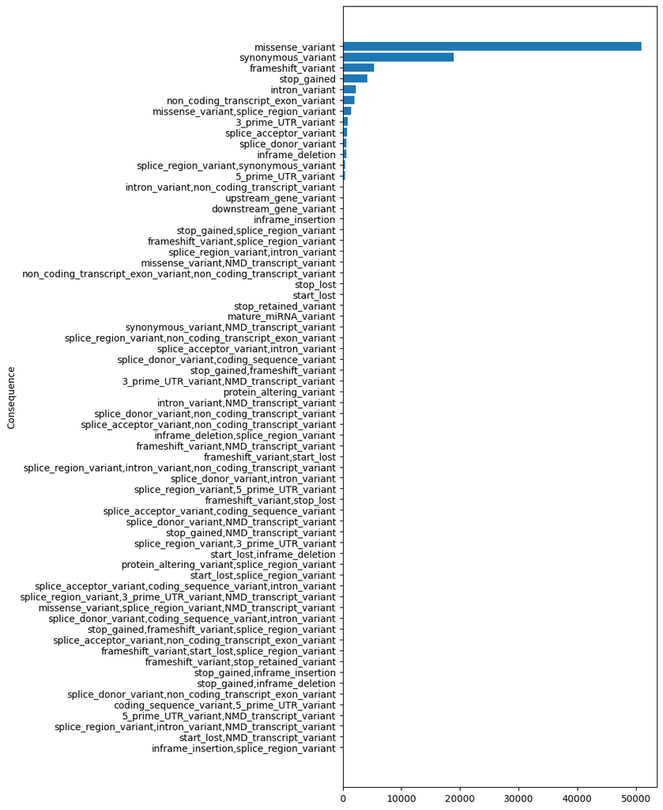

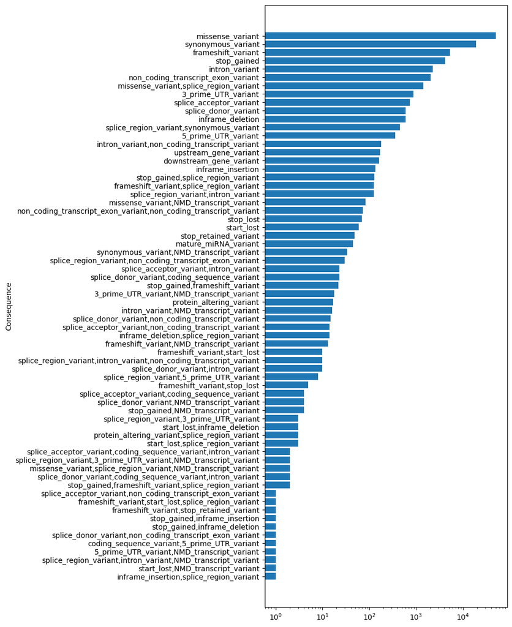

```python
# remove the nan
print(len(data2_disc['Consequence']))
conseq = data2_disc['Consequence'][~data2_disc['Consequence'].isna()]
# type(conseq)
print(len(conseq))

df_plt_conseq = pd.DataFrame({
    "Consequence": Counter(conseq).keys(),
    "Frequency": Counter(conseq).values(),
}).sort_values(by = "Frequency", ascending=True)
# display(df_plt_conseq)

plt.figure(figsize=(6, 15))  # taller figure
plt.barh(y = df_plt_conseq['Consequence'], width = df_plt_conseq['Frequency'], height=0.8)
plt.ylabel('Consequence')
# plt.xscale('log')
plt.show()

plt.figure(figsize=(6, 15))  # taller figure
plt.barh(y = df_plt_conseq['Consequence'], width = df_plt_conseq['Frequency'], height=0.8)
plt.ylabel('Consequence')
plt.xscale('log')
plt.show()
```

# Correlations (5 points)

In general, which are more correlated, the expression profiles between patients (columns) or the expression profiles between genes (rows)? Provide all code and data visualizations used to reach your answer. Does this make sense biologically?

## Calculation

```python
mat = data2_cont.iloc[:, 2:].to_numpy()
print(mat.shape) # 20531 genes total

# Found that some variables has std=0 from matrix calculation
gene_std = mat.std(axis=1)
print(np.where(gene_std!=0)[0])
keep_genes_idx = np.where(gene_std!=0)[0].tolist()
print(len(keep_genes_idx))

patient_std = mat.std(axis=0)
print(np.where(patient_std==0)) # -> patients good to go

# Filter genes
mat_filtered = mat[(gene_std != 0), :]
print(mat_filtered.shape) #20251 genes left

# Store labels for plotting
row_lab = data2_cont['Hugo_Symbol'][keep_genes_idx]
col_lab = data2_cont.iloc[:, 2:].columns.tolist()
```

```
(20531, 1100)
[    0     1     2 ... 20528 20529 20530]
20251
(array([], dtype=int64),)
(20251, 1100)
```

```python
# Calculate corr
r_genes = np.corrcoef(mat_filtered, rowvar=True) #genes are variables -> corr between genes
print(f'r_genes: {r_genes.shape}')

r_patients = np.corrcoef(mat_filtered, rowvar=False) #patients are variable -> corr between patients
print(f'r_patients: {r_patients.shape}')
```

```
r_genes: (20251, 20251)
r_patients: (1100, 1100)
```

```python
# Get lower-triangular matrix to calculate mean correlation
def calc_mean_corr(full_corr_mat):
    lowerTrigMat_row, lowerTrigMat_col = np.tril_indices_from(full_corr_mat, k=-1) #k = 0 (the default) is the main diagonal, k < 0 is below it and k > 0 is above.
    lowerTrigMat = full_corr_mat[lowerTrigMat_row, lowerTrigMat_col]
    mean_corr = np.nanmean(lowerTrigMat)
    return mean_corr

mean_r_genes = calc_mean_corr(r_genes)
print('Mean gene-gene correlation:', mean_r_genes)

mean_r_patients = calc_mean_corr(r_patients)
print('Mean patient-patient correlation:', mean_r_patients)
```

```
Mean gene-gene correlation: 0.006412467951940838
Mean patient-patient correlation: 0.5881177764724647
```

## Visualization

```
(100, 100)
```

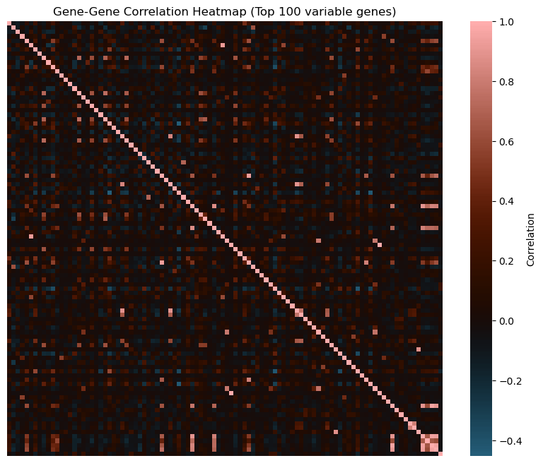

```python
# Heatmap for top variable genes (n=100)
top_var_idx = np.argsort(mat_filtered.std(axis=1))[-100:] #small to large (last 100)
r_topVar_genes = np.corrcoef(mat_filtered[top_var_idx, :], rowvar=True)
# print(mat_filtered[top_var_idx, :].shape)
print(r_topVar_genes.shape)

plt.figure(figsize=(10, 8))
sns.heatmap(r_topVar_genes,
            square = True, xticklabels = False, yticklabels = False,
            cbar_kws={'label': 'Correlation'}, cmap='berlin', #low values are close to black
            center=0) #center the colormap at 0
plt.title("Gene-Gene Correlation Heatmap (Top 100 variable genes)")
plt.show()
```

```
(20251, 100)
(100, 100)
```

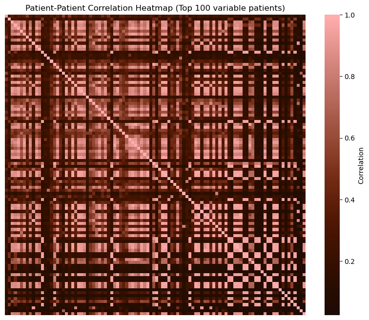

```python
# Heatmap for top 100 variable patients
top_var_idx = np.argsort(mat_filtered.std(axis=0))[-100:] #small to large (last 100)
r_topVar_patients = np.corrcoef(mat_filtered[:,top_var_idx], rowvar=False)
print(mat_filtered[:,top_var_idx].shape)
print(r_topVar_patients.shape)

plt.figure(figsize=(10, 8))
sns.heatmap(r_topVar_patients,
            square = True, xticklabels = False, yticklabels = False,
            cbar_kws={'label': 'Correlation'}, cmap='berlin', #low values are close to black
            center=0) #center the colormap at 0
plt.title("Patient-Patient Correlation Heatmap (Top 100 variable patients)")
plt.show()
```

## Answer

My prediction:

1. In general, **the correlation between genes should be stronger than that between patients** because patients should be independent and heterogeneous, but genes are known to have co-expression modules.
2. Given that this is TCGA data, if the patients in the data shared the same cancer type and the tissues used for sequencing were also the same, computing the correlation between patients (using their global expression profilings) would actually show a high level of correlation due to the shared cancer hallmark gene expression and pathways. This would actually lead to a **globally stronger correlation than the correlation between genes** (since only a subset, cancer hallmark gene sets, would show high correlation, as we can see from the lower right corner from the gene-gene correlation plot above).

The mean correlations also reflect the second point of view

```
Mean gene-gene correlation: 0.006412467951940838
Mean patient-patient correlation: 0.5881177764724647
```

This is biologically reasonable.